# TIM - TP8 : Récapitulatif des séances pratiques + Examen Blanc

Aujourd'hui, la séance est 2 parties et est faite pour vous préparer à l'examen pratique en janvier. Ce TP n'est pas à rendre non plus : en 4A, vous êtes grands, donc je vous laisse décider pour vous.

Un dépôt sera disponible et vous pourrez déposer votre TP si vous voulez un retour perso sur le travail effectué (en fonction du temps que je pourrais y consacrer...).

C'est parti !

### Comptage de grains de riz (oui, on part sur une application très utile dans la vie...)

Eh oui, le but de cet exercice est de compter le nombre de grains de riz dans une image. Pour cela, l'exercice est décomposé en 3 parties :

- Le développement de l'algorithme de binarisation avec seuil automatique (Otsu)
- Le comptage de grains de riz et l'analyse du résultat obtenu
- Les propositions et implémentations de solutions pour améliorer le résultat précédemment obtenu.

### Partie 1 : Binarisation

Une fonction de binarisation vise à transformer une image en niveaux de gris en une image binaire. Dans la plupart des méthodes, les pixels dont les niveaux de gris sont inférieurs à une valeur seuil sont transformés en pixels noirs dans l'image résultat alors que les autres sont transformés en pixels blancs. Mais comment choisir le meilleur seuil pour une image donnée ?

Il existe plusieurs méthodes dans la littérature permettant de déterminer automatiquement le seuil de binarisation. Une des plus connues est la méthode d'Otsu proposée en 1979. Cette méthode a pour hypothèse que les pixels se répartisse en 2 classes (objet et fond), relativement bien distinctes dans l'histogramme.

#### a) Le principe de l'algorithme d'Otsu

On considère une image $I$ de taille $l \times h$ dont les niveaux de gris appartiennent à $[0,L]$. On appelle $h$ l'histogramme d'amplitude défini de telle sorte que $h(n)$ donne le nombre de pixels de $I$ dont le niveau de gris vaut $n$.

La probabilité $p(n)$ a priori d'un niveau de gris $n$ est alors définie par \begin{equation*} p(n) = \frac{h(n)}{l.h} \end{equation*}

La fonction $p(x)$ est alors une densité de probabilité. En effet, on peut alors vérifier que \begin{equation*} \sum_{n=0}^{L} p(n) = 1 \end{equation*}

Il est alors possible de déterminer la moyenne et la variance des niveaux de gris. \begin{equation*} \mu = \sum_{n=0}^{L}n.p(n) \end{equation*}

\begin{equation*} \sigma^2 = \sum_{n=0}^{L}(n-\mu)^2 p(n) \end{equation*}

La méthode d'Otsu repose sur l'hypothèse que les pixels de l'image appartiennent à deux classes $C_{1}$ et $C_{2}$. Si on décide que les pixels appartiennent à $C_{1}$ si leur niveau est inférieur ou égal à t et appartiennent à $C_{2}$ sinon, on peut calculer la probabilité a priori de $C_{1}$ et $C_{2}$. \begin{equation*} P(C_{1}) = \sum_{n=0}^{t} p(n) \end{equation*} \begin{equation*} P(C_{2}) = \sum_{n=t+1}^{L} p(n) \end{equation*}

Les moyennes et variances des niveaux de gris de $C_{1}$ et $C_{2}$ sont alors donnés par \begin{equation*} \mu_{C_{1}} = \frac{\sum_{n=0}^{t} n.p(n)}{P(C_{1})} \end{equation*} \begin{equation*} \mu_{C_{2}} = \frac{\sum_{n=t+1}^{L} n.p(n)}{P(C_{2})} \end{equation*} \begin{equation*} \sigma^2_{C_{1}} = \frac{\sum_{n=0}^{t}(n-\mu_{C_{1}})^2 p(n)}{P(C_{1})} \end{equation*} \begin{equation*} \sigma^2_{C_{2}} = \frac{\sum_{n=t+1}^{L}(n-\mu_{C_{2}})^2 p(n)}{P(C_{2})} \end{equation*}

On montre que \begin{equation*} \mu = \mu_{C_{1}}.P(C_{1})+\mu_{C_{2}}.P(C_{2}) \end{equation*}

Par ailleurs, on appelle $\sigma^2_{intra}$ la variance intraclasse et $\sigma^2_{inter}$ la variance interclasse définies par \begin{equation*} \sigma^2_{intra} = P(C_{1})\sigma^2_{C_{1}} + P(C_{2})\sigma^2_{C_{2}} \end{equation*}

\begin{equation*} \sigma^2_{inter} = P(C_{1})(\mu_{C_{1}}-\mu)^2+P(C_{2})(\mu_{C_{2}}-\mu)^2 \end{equation*}

On montre que \begin{equation*} \sigma^2 = \sigma^2_{intra} + \sigma^2_{inter} \end{equation*}

$\sigma^2$, la variance des niveaux de gris de l'image, est indépendante du seuil de binarisation. En revanche, $\sigma^2_{intra}$ et $\sigma^2_{inter}$ dépendent de la séparation en classes. Selon Otsu, la séparation optimale est obtenue en minimisant la variance intraclasse et en maximisant la variance interclasse. Or la somme de ces deux variances est constante, de ce fait, maximiser la variance interclasse est équivalent à minimiser la variance intraclasse. Le seuil idéal est alors obtenu pour le maximum de $\sigma^2_{inter}$ ou pour le minimum de $\sigma^2_{intra}$. Toutes les valeurs de seuil possibles sont parcourues, et à chaque valeur possible, on calcule la variance $\sigma^2_{intra}$ ou la variance $\sigma^2_{inter}$, au choix, et on choisit le seuil $t$ tel que ces variances sont max ou min :

\begin{equation*} t_{opt} = arg \min_{t \in [0,255]} \sigma^2_{intra}(t) = arg \max_{t \in [0,255]} \sigma^2_{inter}(t) \end{equation*}

#### b) L'algorithme d'Otsu en détail

C'est bien beau tout ce discours sur ce qu'est l'algorithme d'Otsu, mais on l'implémente comment ?

Pour cela, on va tout simplement calculer la variance interclasse pour toutes les valeurs de seuils possibles (allant du niveau de gris **minimum** actuel de l'image au niveau de gris **maximum** actuel de l'image).

**1)** Commencez déjà par implémenter une fonction permettant d'obtenir l'histogramme des niveaux de gris d'une image. On considèrera que notre image est de type uint8.

```python
import numpy as np
from matplotlib import pyplot as plt
import cv2
```

```python
# A compléter
# Fonction d'histogramme des niveaux de gris d'une image
def histogram(image,L):
    hist = np.zeros((L),dtype=np.uint64)
    val_unique = np.unique(image)
    for i in val_unique:
        hist[i] = np.sum(image==i)
    return hist
```

**2)** Maintenant, créez une fonction calculant la probabilité qu'un pixel soit de valeur n dans notre image.

```python
# A compléter
# Fonction de calcul de la probabilité
def proba(histogramme,n):
    return histogramme[n]/np.sum(histogramme)
```

**3)** On continue avec des fonctions assez simples. Tout de suite : l'implémentation du calcul de $\mu$ à partir de l'histogramme.

```python
# Calcul de mu
def mu(histogramme):
    return np.sum([i*proba(histogramme,i) for i in range(0,histogramme.size)])
```

**4)** Implémentez ensuite une fonction de calcul de la variance interclasse d'une image à un seuil t donné.

```python
# A compléter
# Fonction de calcul de la variance interclasse
def var_interclasse(histogramme,t,L,img_mu):
    # Calcul de P(C1) et P(C2)
    P_C1 = np.sum([proba(histogramme,i) for i in range(0,t+1)])
    P_C2 = np.sum([proba(histogramme,i) for i in range(t+1,L)])

    # Calcul de mu_C1 et mu_C2
    mu_C1 = np.sum([i*proba(histogramme,i) for i in range(0,t+1)])/P_C1
    mu_C2 = np.sum([i*proba(histogramme,i) for i in range(t+1,L)])/P_C2

    # Calcul de la variance interclasse
    return P_C1*np.power(mu_C1-img_mu,2)+P_C2*np.power(mu_C2-img_mu,2)
```

**5)** Maintenant, implémentez tout simplement la fonction de détermination du seuil automatique.

```python
# A compléter
# Fonction de détermination du seuil
def find_seuil(image):
    # Calcul de l'histogramme
    histogramme = histogram(image,256)

    # Calcul de la moyenne mu
    image_mu = mu(histogramme)

    # Calcul de la variance interclasse pour chaque seuil possible
    var_inter = np.zeros(256,dtype=np.float64)
    for i in range(image.min(),image.max()):
        var_inter[i] = var_interclasse(histogramme,i,256,image_mu)

    # Calcul du seuil maximisant la variance interclasse
    return np.argmax(var_inter)
```

**6)** On finit par implémenter la fonction de binarisation Otsu

```python
# A compléter
# Fonction de binarisation Otsu
def bin_otsu(image):
    seuil = find_seuil(image)
    return 255*(image>=seuil).astype(np.uint8),seuil
```

**7)** Importez l'image rice.tif et affichez la

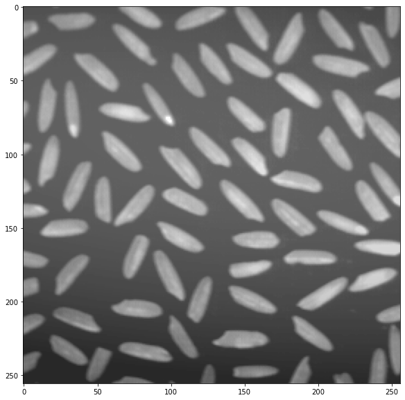

```python
# A compléter
# Import et affichage de l'image rice.tif

import numpy as np
import cv2
import matplotlib.pyplot as plt

rice = cv2.imread('../Base_images/rice.tif',0)
plt.subplots(1,1,figsize=(10,10))
plt.imshow(rice,'gray',vmin=0,vmax=255)
plt.show()
```

**8)** Appliquez la binarisation Otsu sur cette image et affichez le résultat

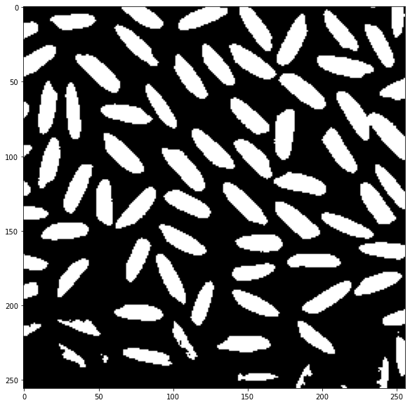

```python
# A compléter
# Binarisation Otsu et affichage du résultat
rice_bin, seuil_bin = bin_otsu(rice)
plt.subplots(1,1,figsize=(10,10))
plt.imshow(rice_bin,'gray')
```

**9)** Comparez votre résultat avec la fonction proposée par OpenCV (cv2.threshold)

```python
# A compléter
# Comparaison du résultat de votre implémentation avec celui d'OpenCV

opencv_seuil_bin,opencv_rice_bin = cv2.threshold(rice,0,255,cv2.THRESH_OTSU)
print("Seuil trouvé par Otsu via votre implémentation : {}".format(seuil_bin))
print("Seuil trouvé par Otsu via OpenCV : {}".format(opencv_seuil_bin))
```

```
Seuil trouvé par Otsu via votre implémentation : 125
Seuil trouvé par Otsu via OpenCV : 125.0
```

*POUR LA SUITE DE L'EXERCICE :* Si votre algorithme n'obtient pas le même résultat que celui proposé par OpenCV, **vous utiliserez la fonction d'OpenCV pour la suite**. Si vous avez bien implémenté l'algorithme, la binarisation Otsu devrait vous donner le résultat suivant :

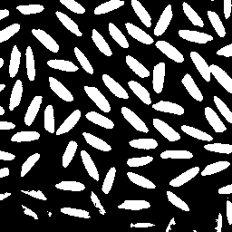

Dans le cas ultime où ni votre implémentation, ni l'utilisation de la fonction Otsu d'OpenCV ne vous donne ce résultat, **vous avez l'image résultat dans votre base d'image** (rice_bin.png). Il vous suffit donc de l'importer pour continuer le TP en toute tranquilité.

### Partie 2 : Le comptage de grains de riz

**10)** Maintenant, passons au moment le plus fun : le comptage des grains de riz ! On va le faire automatiquement évidemment. Pour cela, utilisez les fonctions regionsprops et label de skimage.measure, couplés avec label2rgb de skimage.color.

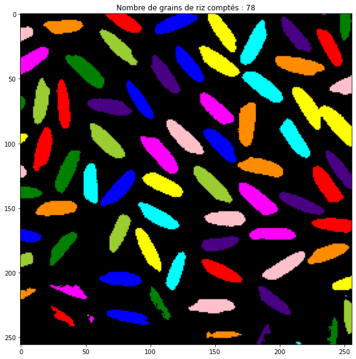

```python
from skimage.measure import regionprops,label
from skimage.color import label2rgb

# On labelise les régions de l'image binarisée (en gros les grains de riz quoi...)
labels = label(rice_bin)

# On récupère ensuite les données des régions labelisées
regions = regionprops(labels)

# Et là, on va créer une image bien sympathique
output = label2rgb(labels,bg_label=0)
output[rice_bin==0]=0

plt.subplots(1,1,figsize=(10,10))
plt.imshow(output)
plt.title("Nombre de grains de riz comptés : {}".format(len(regions)))
plt.show()
```

**11)** Histoire d'aller plus loin, on a ici quelques soucis dans notre binarisation avec seuillage automatique. En effet, certains grains de riz ne sont pas détectés, et nous avons des régions mal labelisées, comme celles ci-dessous :

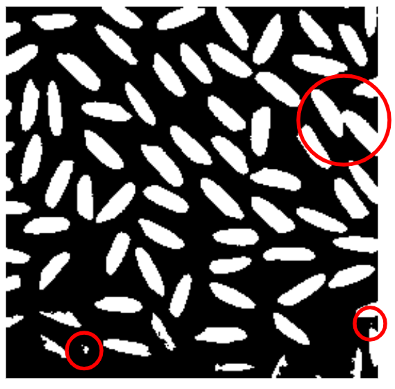

De plus, lors de la binarisation, nous avons perdu quelques grains de riz en bas de l'image. Il va donc falloir proposer des améliorations à notre algorithme de comptage.

### Partie 3 : Propositions et implémentations de solutions pour améliorer le résultat.

**12)** A partir des résultats obtenus avec la segmentation Otsu et le code de comptage qui vous est fourni, proposez une ou plusieurs solutions en pré-traitement, traitement ou post-traitement pour améliorer l'algorithme existant. En plus du code demandé, nous vous demandons une analyse avec explication des choix d'algorithmes et de paramètres.

Cherchez déjà à comprendre le problème principal sur votre image qui fait que la segmentation Otsu ne fonctionne pas parfaitement. Pour cela, vous pouvez essayer temporairement plusieurs binarisations à différents seuils, et analyser le résultat.

*Indice plus ou moins subtil :* Faites abstraction des grains de riz...

*Analyse des résultats et description du problème principal :* Le problème principal ici est l'arrière-plan (background pour ceux qui ont validé le TOIEC ;) ). En effet, il est loin d'être uniforme, et il faut pour cela l'uniformiser en le mettant tout en noir, tout en affectant le moins possible les grains de riz.

*Solution(s) proposée(s) :* Ici, j'utilise la morphologie mathématique en pré-traitement afin d'éliminer les grains de riz, dans l'objectif d'avoir uniquement l'arrière-plan d'image. Je soustrais ensuite l'arrière-plan obtenu à notre image originale, pour avoir un arrière-plan plus sombre, tout en gardant le mieux possible les grains de riz.

J'ai choisi ici un kernel elliptique de taille 21X21 pour pouvoir englober les grains de riz.

```python
# Création du kernel pour la morphologie mathématique
kernel = cv2.getStructuringElement(cv2.MORPH_ELLIPSE,(21,21))
kernel.shape
```

```
(21, 21)
```

Je réalise ensuite une ouverture sur mon image via ce kernel.

```python
# Ouverture de notre image avec notre kernel construit
background = cv2.morphologyEx(rice,cv2.MORPH_OPEN,kernel)
```

Grâce à cette ouverture, je n'ai plus de grains de riz, mais uniquement l'arrière-plan.

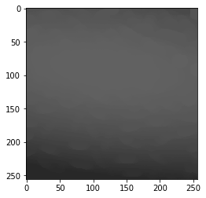

```python
# Affichage du résultat de notre ouverture : le fond de notre image
plt.imshow(background,'gray',vmin=0,vmax=255)
```

Je peux ensuite soustraire l'arrière-plan non uniforme de mon image à mon image originale. Je fais attention à ne pas avoir de valeur négative dans mon résultat (gestion des types de données Numpy).

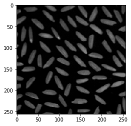

```python
# Calcul de notre nouvelle image (avec gestion des types)
new_rice = np.maximum(rice.astype(np.int16)-background.astype(np.int16),0).astype(np.uint8)

# Affichage de notre nouvelle image à traiter
plt.imshow(new_rice,'gray',vmin=0,vmax=255)
```

L'arrière-plan ici est très foncé et les grains de riz sont bien visibles. On peut déjà appliquer la segmentation Otsu.

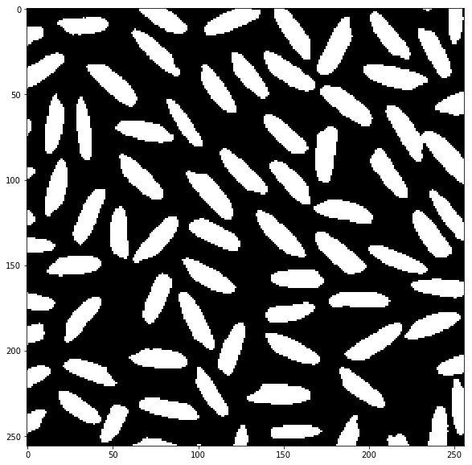

```python
# Segmentation Otsu de notre nouvelle image
new_rice_bin,seuil_new_rice_bin = bin_otsu(new_rice)

# Affichage du résultat de segmentation
plt.subplots(1,1,figsize=(10,10))
plt.imshow(new_rice_bin,'gray')
```

Le résultat est plutôt propre : on n'a pas de bruit comme précédemment, et tous nos grains de riz sont bien segmentés. On a juste deux grains de riz collés, comme précédemment. On peut tenter une érosion en post-traitement, mais on risque d'impacter les régions plus petites (grains de riz coupés sur le bord de l'image).

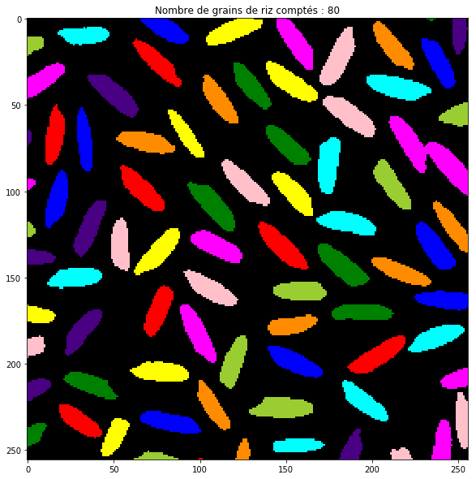

```python
# On labelise les régions de l'image binarisée (en gros les grains de riz quoi...)
labels = label(new_rice_bin)

# On récupère ensuite les données des régions labelisées
regions = regionprops(labels)

# Et là, on va créer une image bien sympathique
output = label2rgb(labels)
output[new_rice_bin==0]=0

plt.subplots(1,1,figsize=(10,10))
plt.imshow(output)
plt.title("Nombre de grains de riz comptés : {}".format(len(regions)))
plt.show()
```

On va pouvoir maintenant vérifier que les contours de chaque grain de riz correspondent à l'image originale.

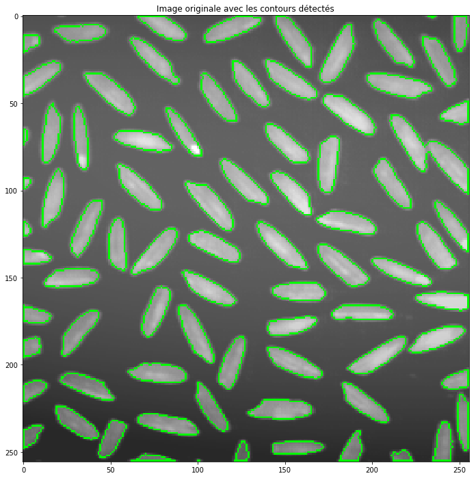

```python
contours,__ = cv2.findContours(new_rice_bin,cv2.RETR_TREE,cv2.CHAIN_APPROX_SIMPLE)
new_output = cv2.cvtColor(rice,cv2.COLOR_GRAY2RGB)
for cnt in contours:
    cv2.polylines(new_output,[cnt],1,(0,255,0))
plt.subplots(1,1,figsize=(12,12))
plt.imshow(new_output)
plt.title("Image originale avec les contours détectés")
plt.show()
```

*Analyse de la ou les solution(s) proposée(s) :* Ici, on a réglé le problème principal, à savoir la non détection des grains de riz de la partie basse de l'image. Le résultat est plutôt satisfaisant, car tous les grains de riz sont bien détectés, et les contours correspondent plutôt bien, même s'ils sont plus réduits que ceux que l'on pourrait déduire depuis l'image originale. Il reste toujours le problème des 2 grains de riz collés.

*Pour aller plus loin :* Comment décoller les 2 grains de riz ?

Ici, je vous présente une méthode dans le cas où vous avez des grains de riz collés. Ce sont ici des algorithmes que nous n'avons pas vu en cours/TP, donc bien évidemment, je ne vous noterai pas sur cette partie-là : c'est juste pour votre curiosité ;)

On commence déjà par définir notre image en 3 classes : 1 classe pour les pixels où on est sûr que ce sont des grains de riz, 1 classe pour les pixels où on est sûr que c'est l'arrière-plan, et une dernière classe où on ne sait pas vraiment...

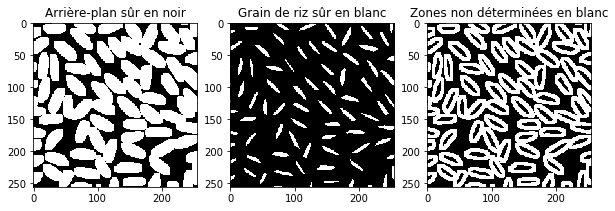

```python
# On agrandit l'image, histoire de pouvoir bien analyser les petits grains de riz
#new_rice_bin = cv2.resize(new_rice_bin,(1024,1024))

# On détermine les zones où on est sûr que c'est l'arrière-plan
kernel = cv2.getStructuringElement(cv2.MORPH_RECT,(3,3))
sure_bg = cv2.dilate(new_rice_bin,kernel,iterations=3)

# On détermine les zones où on est sûr que c'est du grain de riz
dist_transform = cv2.distanceTransform(new_rice_bin,cv2.DIST_L2,5)
ret, sure_fg = cv2.threshold(dist_transform,0.4*dist_transform.max(),255,0)

# On détermine ensuite les zones inconnues en fonction des 2 autres représentations
sure_fg = np.uint8(sure_fg)
unknown = cv2.subtract(sure_bg,sure_fg)

plt.subplots(1,3,figsize=(10,10))
plt.subplot(131)
plt.imshow(sure_bg,'gray')
plt.title("Arrière-plan sûr en noir")
plt.subplot(132)
plt.imshow(sure_fg,'gray')
plt.title("Grain de riz sûr en blanc")
plt.subplot(133)
plt.imshow(unknown,'gray')
plt.title("Zones non déterminées en blanc")
plt.show()
```

De la même manière que précédemment, on va labelliser nos zones sûres (grain de riz ou arrière-plan) en leur attribuant une valeur supérieure à 1 pour les grains de riz (zone colorées) ou 1 pour l'arrière-plan (noir). Les zones indécises seront initialisées à 0 (zones grises).

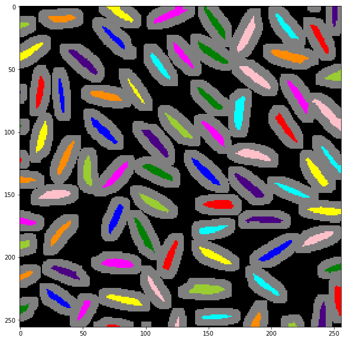

```python
# Labellisation des zones grain de riz sûres
ret, markers = cv2.connectedComponents(sure_fg)

# On ajoute 1 à tous les labels, pour laisser la zone unknown ensuite à 0
markers = markers+1
markers[unknown==255] = 0

# Affichage de notre image labelisée
markers_output = label2rgb(markers)
markers_output[markers==1]=[0,0,0]
markers_output[markers==0]=[0.5,0.5,0.5]

plt.subplots(1,1,figsize=(10,10))
plt.imshow(markers_output,cmap='jet')
plt.show()
```

On va ensuite utiliser un algorithme super cool appelé Watershed. Son objectif ici est d'attribuer une classe définie (valeur>0) aux pixels non définis (valeur=0, pixels gris) en fonction de l'entourage, grâce à ce qu'on appelle des markers, à savoir des zones où l'on est sûr qu'elles appartiennent à une classe définie (ici, tous les pixels avec une valeur > 0).

Pour plus de détails sur cet algorithme qui gère la fougère (oui, pas terrible comme expression...) : https://fr.wikipedia.org/wiki/Ligne_de_partage_des_eaux_(segmentation)

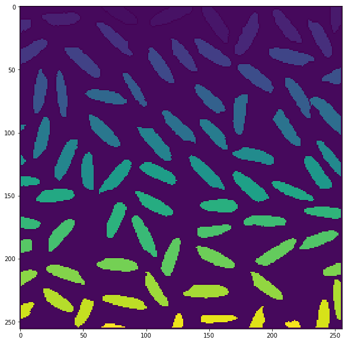

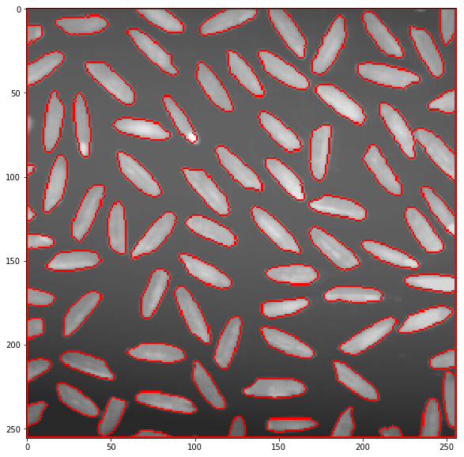

```python
# Application du Watershed pour redélimiter les contours des grains de riz
output = cv2.cvtColor(rice,cv2.COLOR_GRAY2RGB)
markers = cv2.watershed(output,markers)

# Visualisation des zones labelisées avec Watershed
plt.subplots(1,1,figsize=(10,10))
plt.imshow(markers)
plt.show()

# Extraction des contours de nos zones
output[markers == -1] = [255,0,0]
plt.subplots(1,1,figsize=(10,10))
plt.imshow(output)
plt.show()
```

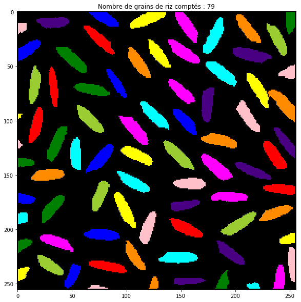

```python
# Et on finit par le comptage des grains de riz
markers[markers==-1]=1
regions = regionprops(markers)
output = label2rgb(markers)
output[markers==1]=0

plt.subplots(1,1,figsize=(10,10))
plt.imshow(output)
plt.title("Nombre de grains de riz comptés : {}".format(len(regions)))
plt.show()
```

Entre temps, on a perdu 2 bouts de grain de riz sur le bord de l'image... Mais est-ce que cela est vraiment important ?

Plus sérieusement, tout dépend de la tâche que vous souhaitez faire, mais ici, la distinction des 2 grains de riz collés est plus importante que la détection des 2 bouts ridicules sur le bord.